# River model: impact of nutrients and dams on food web structure

## Todo

- Join AMOBIO stressors + distance to mouth to river food web structure
- Checkpoint: coverage and missingness of covariates
- Checkpoint: spatial/temporal coverage and response distributions
- Decide how to handle nutrient / dam-distance-downstream missingness
- Build SPDE mesh over river station locations (Lambert-93)
- Fit richness ~ nutrients + dams * distance to mouth + year + SPDE (path *a*)
- Checkpoint: richness model diagnostics and predictions
- Fit connectance / trophic length / diet overlap ~ richness + nutrients + dams * distance to mouth + year + SPDE (paths *b* and *c’*)
- Checkpoint each model
- Direct/indirect effect decomposition (product of coefficients, via posterior samples)
- Swap Euclidean SPDE for a `MetricGraph` hydrographic-distance spatial term (Bolin et al. 2023)

```r
library(renv)
renv::load()
library(targets)
library(here)
tar_config_set(
  store = here::here("_targets")
)
library(ggplot2)
library(dplyr)
library(sf)
devtools::load_all()
nice_theme()
knitr::opts_chunk$set(autodep = TRUE)
```

## Data preparation

We join two dataframes:

- AMOBIO environmental stressors (nutrients and dams), already matched with food web structure (`amobio_aspe_data`);
- and hydrographic distance to river mouth (`inland_distance_to_mouth`)

```r
amobio <- tar_read(amobio_aspe_data) |> st_drop_geometry()
head(amobio)
```

```
# A tibble: 6 × 30
  node_id elevation sandre_code date       dam_distance_downstream
    <int>     <dbl> <chr>       <date>                       <dbl>
1    1471      401. 06166990    2019-07-19                  16194.
2    2072     1195. 06169880    2020-06-26                  23251.
3    2958     1730. 06175400    2019-08-28                   5020.
4    2958     1730. 06175400    2020-09-02                   5020.
5    4891      248. 06170000    2010-09-15                   5429.
6    4891      248. 06170000    2020-09-23                   5429.
# ℹ 25 more variables: dam_distance_upstream <dbl>, barrier_upstream <dbl>,
#   barrier_downstream <dbl>, total_phosphorus <dbl>, phosphate <dbl>,
#   nitrate <dbl>, nitrite <dbl>, ammonium <dbl>, kjeldahl_nitrogen <dbl>,
#   operation_id <chr>, foodweb <list>, log_trophic_richness <dbl>,
#   log_species_richness <dbl>, connectance <dbl>, trophic_length <dbl>,
#   trophic_breadth_q90 <dbl>, trophic_breadth_median <dbl>,
#   frac_piscivorous <dbl>, diet_overlap <dbl>, year <dbl>, month <dbl>, …
```

```r
dist_mouth <- tar_read(inland_distance_to_mouth) |>
  select(operation_id, district, dist_mouth_m)
head(dist_mouth)
```

```
  operation_id district dist_mouth_m
1     61839708    Loire     9748.079
2     61837714    Loire    13929.441
3     61839934    Loire    70160.395
4     61832476    Loire    56470.216
5     61831599    Loire    56775.685
6     61836649    Loire    72253.213
```

```r
river_width <- tar_read(river_width)
head(river_width)
```

```
# A tibble: 6 × 2
  sandre_code river_width
  <chr>             <dbl>
1 01000172           14.5
2 01000274           13.6
3 01000477            8
4 01000602           11.5
5 01000605           14.9
6 01000729           13.0
```

`amobio` and `dist_mouth` both carry `operation_id`, drawn from the same ASPE ID space, so they join directly. `river_width` is station-level (Naiades hydromorphology survey, averaged across all available visit dates per station), so it joins on `sandre_code`.

```r
river_data <- amobio |>
  inner_join(dist_mouth, by = "operation_id") |>
  left_join(river_width, by = "sandre_code") |>
  select(
    operation_id, sandre_code, year, survey, district, longitude, latitude,
    log_species_richness, connectance, trophic_length, diet_overlap,
    elevation, river_width,
    ammonium, nitrite, nitrate, phosphate,
    dam_distance_upstream, dam_distance_downstream,
    barrier_upstream, barrier_downstream,
    dist_mouth_m
  )

head(river_data)
```

```
# A tibble: 6 × 22
  operation_id sandre_code  year survey district       longitude latitude
  <chr>        <chr>       <dbl> <chr>  <chr>              <dbl>    <dbl>
1 24770        05173300     2009 river  Ardour-Garonne      1.45     42.6
2 24762        05173300     2017 river  Ardour-Garonne      1.45     42.6
3 24249        05173400     2009 river  Ardour-Garonne      1.79     42.7
4 25031        05173400     2015 river  Ardour-Garonne      1.79     42.7
5 25002        05180700     2014 river  Ardour-Garonne      1.38     42.8
6 82390        05180700     2019 river  Ardour-Garonne      1.38     42.8
# ℹ 15 more variables: log_species_richness <dbl>, connectance <dbl>,
#   trophic_length <dbl>, diet_overlap <dbl>, elevation <dbl>,
#   river_width <dbl>, ammonium <dbl>, nitrite <dbl>, nitrate <dbl>,
#   phosphate <dbl>, dam_distance_upstream <dbl>,
#   dam_distance_downstream <dbl>, barrier_upstream <dbl>,
#   barrier_downstream <dbl>, dist_mouth_m <dbl>
```

We go from 8372 river operations with AMOBIO data, and 19045 with a computed distance to mouth, down to 6075 once both are required simultaneously. Most droppped rows are because of the filtering on hydrographic basin kept, and a few stations that are not present in AMOBIO dataset.

## Data overview

### Missing values

```r
vars <- c(
  "ammonium", "nitrite", "nitrate", "phosphate",
  "dam_distance_upstream", "dam_distance_downstream",
  "barrier_upstream", "barrier_downstream", "dist_mouth_m",
  "elevation", "river_width",
  "log_species_richness", "connectance", "trophic_length", "diet_overlap"
)

nutrient_na <- river_data |>
  select(ammonium, nitrite, nitrate, phosphate) |>
  mutate(
    one_is_na = if_any(c(ammonium, nitrite, nitrate, phosphate), is.na),
    all_are_na = if_all(c(ammonium, nitrite, nitrate, phosphate), is.na)
  )

n_one_na <- sum(nutrient_na$one_is_na)
n_all_na <- sum(nutrient_na$all_are_na)
n_mismatch <- sum(nutrient_na$one_is_na & !nutrient_na$all_are_na)

tibble(
  variable = vars,
  n_na = sapply(river_data[vars], \(x) sum(is.na(x))),
  pct_na = round(100 * n_na / nrow(river_data), 1)
) |>
  arrange(desc(n_na))
```

```
# A tibble: 15 × 3
   variable                 n_na pct_na
   <chr>                   <int>  <dbl>
 1 dam_distance_upstream    2450   40.3
 2 river_width              2224   36.6
 3 nitrite                  1928   31.7
 4 ammonium                 1921   31.6
 5 phosphate                1921   31.6
 6 nitrate                  1913   31.5
 7 dam_distance_downstream   340    5.6
 8 barrier_upstream            0    0
 9 barrier_downstream          0    0
10 dist_mouth_m                0    0
11 elevation                   0    0
12 log_species_richness        0    0
13 connectance                 0    0
14 trophic_length              0    0
15 diet_overlap                0    0
```

Two things stand out

- nutrients are missing together, not independently: 1912 of the 1930 rows missing any nutrient are missing *all four* at once, and only 18 rows show a partial mismatch;
- dam upstream distance is missing far more of than the downstream distance (`dam_distance_upstream`/`dam_distance_downstream` were swapped in `rename_amobio()` relative to AMOBIO’s own scale codes - fixed in `R/amobio.R`, pipeline rebuilt).

Coverage for `dam_distance_upstream` is too low, so we drop it from the model. For the other covariates we’ll use complete cases per model.

### Spatial coverage

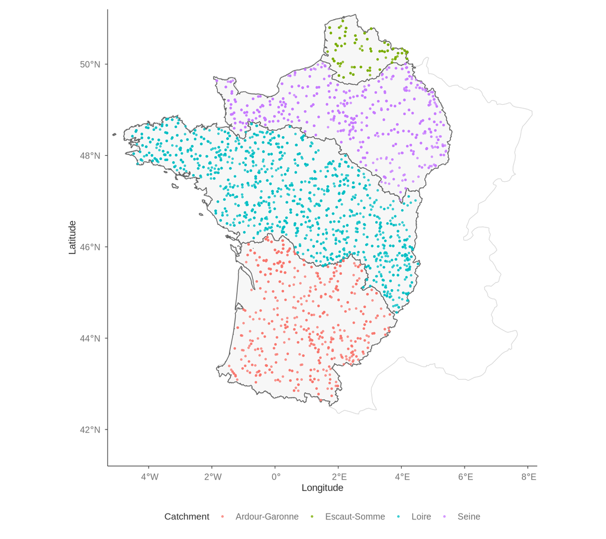

```r
basin <- tar_read(basin)
france <- rnaturalearth::ne_countries(
  geounit = "france", type = "map_units", scale = "medium", returnclass = "sf"
)

ggplot() +
  geom_sf(data = france, fill = NA, color = "grey80", linewidth = 0.25) +
  geom_sf(
    data = basin |> filter(district %in% unique(river_data$district)),
    fill = "grey97", color = "grey40", linewidth = 0.4
  ) +
  geom_point(
    data = river_data, aes(longitude, latitude, color = district),
    size = 0.6, alpha = 0.7
  ) +
  coord_sf(xlim = c(-5.3, 8.3), ylim = c(41.2, 51.2), expand = FALSE) +
  labs(x = "Longitude", y = "Latitude", color = "Catchment") +
  theme(panel.grid = element_blank())
```

Good coverage in all four basin although they vary in sizes.

### Temporal coverage

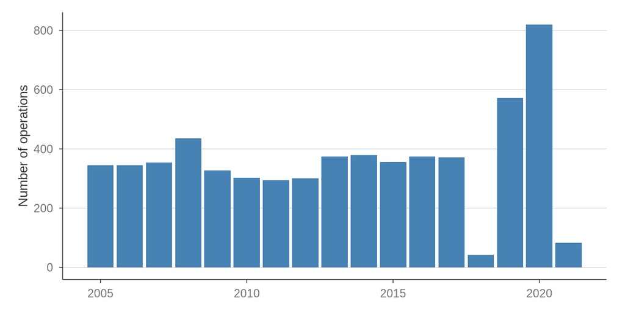

```r
ggplot(river_data, aes(year)) +
  geom_bar(fill = "steelblue") +
  labs(x = NULL, y = "Number of operations")
```

Mostly even coverage, but for 2018 and 2021 which have far less fishing operations.

## Response distributions

Let’s see the distributions of our response variable so we can choose the relevant reponse distributions.

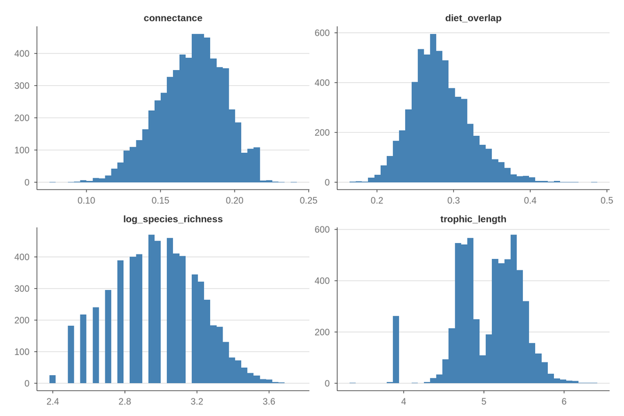

```r
river_data |>
  select(log_species_richness, connectance, trophic_length, diet_overlap) |>
  tidyr::pivot_longer(everything(), names_to = "metric", values_to = "value") |>
  ggplot(aes(value)) +
  geom_histogram(bins = 40, fill = "steelblue") +
  facet_wrap(~metric, scales = "free") +
  labs(x = NULL, y = NULL)
```

Connectance and diet overlap are bounded between 0 and 1; they will be properly modeled by a beta distribution. Log species richness might be handle well by a gaussian distribution. The real thinking should be done for the trophic level which is clearly multimodal. Let’s try to investigate why.

We split each local food web by the predation depth of its top species: does it eat no fish at all, a fish that itself only eats invertebrates, or a fish that is itself piscivorous.

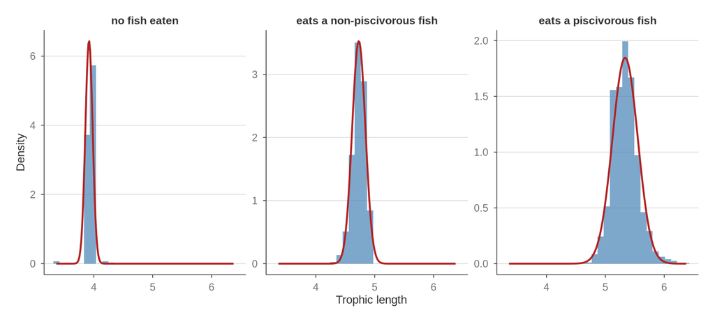

```r
river_foodweb <- tar_read(river_foodweb_structure) |>
  filter(operation_id %in% river_data$operation_id)
resource_list <- tar_read(resource_list)

classify_predation_depth <- function(web, resource_list) {
  nodes <- data.frame(node = colnames(web))
  links <- web |>
    as.data.frame() |>
    mutate(resource = rownames(web)) |>
    tidyr::pivot_longer(-resource, names_to = "consumer") |>
    filter(value == 1) |>
    select(-value)
  community <- cheddar::Community(
    nodes = nodes, properties = list(title = "Community"), trophic.links = links
  )
  tl <- cheddar::TrophicLevels(community) |>
    as.data.frame() |>
    tibble::rownames_to_column("node") |>
    rename(TL = ChainAveragedTL)
  top_nodes <- tl$node[!is.na(tl$TL) & tl$TL == max(tl$TL, na.rm = TRUE)]

  fish_prey_of <- function(n) {
    prey <- rownames(web)[web[, n] == 1]
    prey[!(prey %in% resource_list)]
  }
  top_fish_prey <- unique(unlist(lapply(top_nodes, fish_prey_of)))

  if (length(top_fish_prey) == 0) {
    "no fish eaten"
  } else if (any(sapply(top_fish_prey, \(p) length(fish_prey_of(p)) > 0))) {
    "eats a piscivorous fish"
  } else {
    "eats a non-piscivorous fish"
  }
}

river_foodweb <- river_foodweb |>
  mutate(
    predation_depth = sapply(
      foodweb, classify_predation_depth, resource_list = resource_list
    ),
    predation_depth = factor(
      predation_depth,
      levels = c(
        "no fish eaten", "eats a non-piscivorous fish",
        "eats a piscivorous fish"
      )
    )
  )

tl_range <- range(river_foodweb$trophic_length)
normal_overlay <- river_foodweb |>
  group_by(predation_depth) |>
  summarise(
    mean_tl = mean(trophic_length), sd_tl = sd(trophic_length), .groups = "drop"
  ) |>
  rowwise() |>
  reframe(
    predation_depth = predation_depth,
    x = seq(tl_range[1], tl_range[2], length.out = 200),
    y = dnorm(x, mean_tl, sd_tl)
  )

ggplot(river_foodweb, aes(trophic_length)) +
  geom_histogram(
    aes(y = after_stat(density)), bins = 30, fill = "steelblue", alpha = 0.7
  ) +
  geom_line(
    data = normal_overlay, aes(x, y), color = "firebrick", linewidth = 0.8
  ) +
  facet_wrap(~predation_depth, scales = "free") +
  labs(x = "Trophic length", y = "Density")
```

We see that the ‘predation depth’ cleanly separates our three modes of the trophic level distribution. So we will go for an ordinal model the classify these modes and model each of the mode individually as a gaussian.

## Building the mesh

We build a mesh that covers all fishing stations.

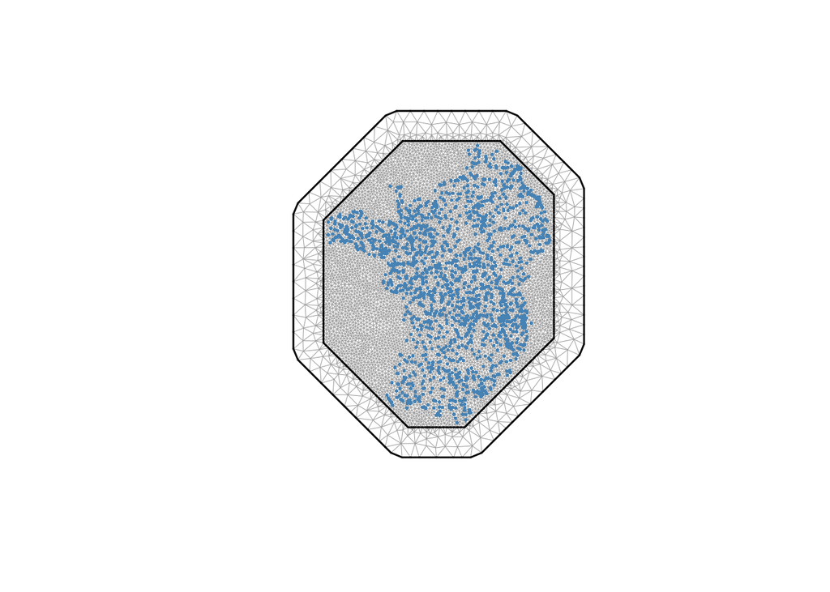

```r
library(INLA)
library(fmesher)

stations <- river_data |>
  distinct(sandre_code, longitude, latitude) |>
  st_as_sf(coords = c("longitude", "latitude"), crs = 4326) |>
  st_transform(2154) # Lambert-93, coordinates in meters.

coords <- st_coordinates(stations)

mesh <- fm_mesh_2d_inla(
  loc = coords,
  max.edge = c(15000, 60000),
  offset = c(15000, 100000),
  cutoff = 5000
)
plot(mesh, edge.color = rgb(0.6, 0.6, 0.6), lwd = 0.5)
points(coords, col = "steelblue", pch = 16, cex = 0.4)
```

```r
spde <- inla.spde2.pcmatern(
  mesh = mesh,
  prior.range = c(50000, 0.5),
  prior.sigma = c(1, 0.01)
)

A <- inla.spde.make.A(mesh = mesh, loc = coords)
spatial_index <- inla.spde.make.index("spatial.field", n.spde = spde$n.spde)

site_idx <- match(river_data$sandre_code, stations$sandre_code)
A_expanded <- A[site_idx, ]
```

### Collinearity check

Before fitting, we check pairwise correlation between covariates, on the same complete-case rows used for fitting, log-transforming the skewed ones first.

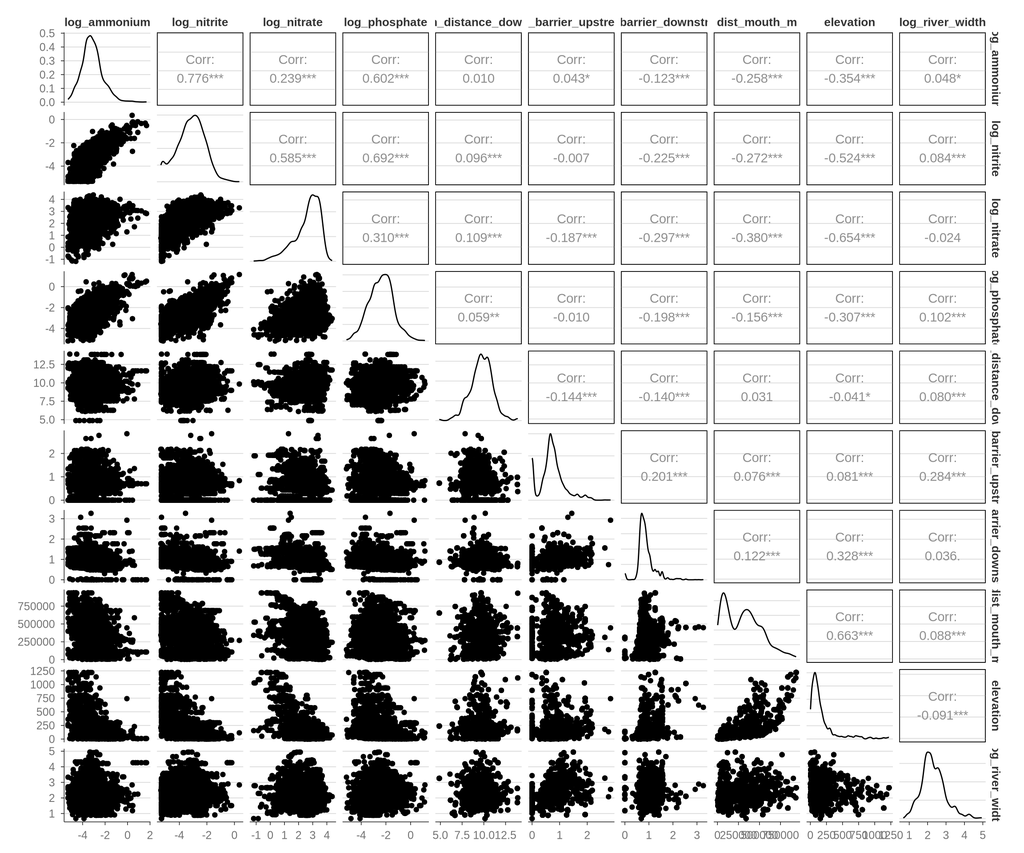

```r
candidate_vars <- c(
  "log_species_richness", "elevation", "river_width",
  "ammonium", "nitrite", "nitrate", "phosphate",
  "dam_distance_downstream", "barrier_upstream", "barrier_downstream",
  "dist_mouth_m", "year", "sandre_code", "district"
)
river_model_data_raw <- river_data |>
  filter(complete.cases(river_data[candidate_vars]))

river_model_data_raw <- river_model_data_raw |>
  mutate(
    log_ammonium = log(ammonium),
    log_nitrite = log(nitrite),
    log_nitrate = log(nitrate),
    log_phosphate = log(phosphate),
    log_dam_distance_downstream = log(dam_distance_downstream),
    log_barrier_upstream = log1p(barrier_upstream),
    log_barrier_downstream = log1p(barrier_downstream),
    log_river_width = log(river_width)
  )

river_model_data_raw |>
  select(
    log_ammonium, log_nitrite, log_nitrate, log_phosphate,
    log_dam_distance_downstream, log_barrier_upstream,
    log_barrier_downstream, dist_mouth_m, elevation, log_river_width
  ) |>
  GGally::ggpairs()
```

We observe a strong correlation between ammonium and the other nutrients, so we decide to drop this variable to ensure model identifiability.

```r
river_model_data_raw <- river_model_data_raw |>
  select(-log_ammonium)
```

Shared term ordering/typing and plotting helper for the coefficient plots of all three structure models below (richness, connectance, predation depth), so it isn’t redefined per model. Also defines the small helpers used to pull named components (fixed effects, random effect vectors, the spatial field) out of an `inla.posterior.sample()` draw, reused by every AME/interaction computation later in the notebook.

```r
get_val <- function(s, name) {
  unname(s$latent[rownames(s$latent) == paste0(name, ":1"), 1])
}
get_re_vec <- function(s, prefix, k) {
  unname(sapply(
    seq_len(k), \(i) s$latent[rownames(s$latent) == paste0(prefix, ":", i), 1]
  ))
}
get_spatial_vec <- function(s) {
  unname(s$latent[grep("^spatial.field:", rownames(s$latent)), 1])
}

term_order <- c(
  "log_species_richness",
  "dist_mouth_m", "elevation", "river_width",
  "nitrate", "nitrate2", "phosphate", "phosphate2",
  "barrier_upstream", "barrier_downstream",
  "barrier_upstream:dist_mouth_m", "barrier_downstream:dist_mouth_m"
)
term_type <- c(
  log_species_richness = "richness",
  dist_mouth_m = "physical", elevation = "physical", river_width = "physical",
  nitrate = "nutrient", nitrate2 = "nutrient",
  phosphate = "nutrient", phosphate2 = "nutrient",
  barrier_upstream = "connectivity", barrier_downstream = "connectivity",
  `barrier_upstream:dist_mouth_m` = "interaction",
  `barrier_downstream:dist_mouth_m` = "interaction"
)

plot_coefficients <- function(fit, x_label) {
  fit$summary.fixed |>
    tibble::rownames_to_column("term") |>
    filter(term %in% term_order) |>
    mutate(
      term = factor(term, levels = rev(term_order)),
      type = term_type[as.character(term)]
    ) |>
    ggplot(aes(mean, term, color = type)) +
    geom_vline(xintercept = 0, linetype = "dashed", color = "grey50") +
    geom_pointrange(aes(xmin = `0.025quant`, xmax = `0.975quant`)) +
    labs(x = x_label, y = NULL, color = "Term type")
}
```

## Richness model

$$\log S_i \sim \mathcal{N}(\mu_i, \sigma_i)$$
$$\mu_i = \mathbf{x}_i^\top \boldsymbol\beta +
\text{year}_i + \text{district}_i +
\text{SPDE}_i$$

where $\mathbf{x}$ is the vector of covariates (nutrients, dams, etc.) and $\beta$ their fixed effect.

```r
river_model_data <- river_model_data_raw |>
  mutate(
    nitrate = log(nitrate),
    phosphate = log(phosphate),
    barrier_upstream = log1p(barrier_upstream),
    barrier_downstream = log1p(barrier_downstream),
    river_width = log(river_width),
    district_id = as.integer(factor(district))
  ) |>
  mutate(across(
    c(
      nitrate, phosphate,
      barrier_upstream, barrier_downstream, dist_mouth_m,
      elevation, river_width
    ),
    \(x) as.numeric(scale(x))
  )) |>
  mutate(nitrate2 = nitrate^2, phosphate2 = phosphate^2)

site_idx_model <- match(river_model_data$sandre_code, stations$sandre_code)
A_model <- A[site_idx_model, ]

richness_stack <- inla.stack(
  data = list(y = river_model_data$log_species_richness),
  A = list(A_model, 1),
  effects = list(
    spatial.field = spatial_index,
    data.frame(
      intercept = 1,
      elevation = river_model_data$elevation,
      river_width = river_model_data$river_width,
      nitrate = river_model_data$nitrate,
      nitrate2 = river_model_data$nitrate2,
      phosphate = river_model_data$phosphate,
      phosphate2 = river_model_data$phosphate2,
      barrier_upstream = river_model_data$barrier_upstream,
      barrier_downstream = river_model_data$barrier_downstream,
      dist_mouth_m = river_model_data$dist_mouth_m,
      year = river_model_data$year,
      district_id = river_model_data$district_id
    )
  ),
  tag = "est"
)

fit_richness <- inla(
  y ~ -1 + intercept +
    elevation + river_width +
    nitrate + nitrate2 + phosphate + phosphate2 +
    barrier_upstream + barrier_downstream +
    dist_mouth_m +
    barrier_upstream:dist_mouth_m +
    barrier_downstream:dist_mouth_m +
    f(year, model = "iid") +
    f(district_id, model = "iid") +
    f(spatial.field, model = spde),
  family = "gaussian",
  data = inla.stack.data(richness_stack),
  control.predictor = list(A = inla.stack.A(richness_stack), compute = TRUE),
  control.compute = list(waic = TRUE, config = TRUE)
)

summary(fit_richness)
```

```
Time used:
    Pre = 1.06, Running = 15.7, Post = 1.85, Total = 18.6
Fixed effects:
                                  mean    sd 0.025quant 0.5quant 0.975quant
intercept                        2.966 0.023      2.913    2.969      3.007
elevation                       -0.102 0.014     -0.129   -0.102     -0.074
river_width                      0.077 0.006      0.065    0.077      0.089
nitrate                         -0.007 0.009     -0.024   -0.007      0.010
nitrate2                        -0.010 0.004     -0.018   -0.010     -0.003
phosphate                        0.017 0.005      0.007    0.017      0.027
phosphate2                       0.001 0.003     -0.004    0.001      0.006
barrier_upstream                 0.008 0.006     -0.004    0.008      0.020
barrier_downstream              -0.008 0.009     -0.024   -0.008      0.009
dist_mouth_m                     0.047 0.013      0.021    0.047      0.073
barrier_upstream:dist_mouth_m    0.008 0.006     -0.004    0.008      0.020
barrier_downstream:dist_mouth_m -0.001 0.009     -0.018   -0.001      0.016
                                  mode   kld
intercept                        2.972 0.001
elevation                       -0.102 0.000
river_width                      0.077 0.000
nitrate                         -0.007 0.000
nitrate2                        -0.010 0.000
phosphate                        0.017 0.000
phosphate2                       0.001 0.000
barrier_upstream                 0.008 0.000
barrier_downstream              -0.008 0.000
dist_mouth_m                     0.047 0.000
barrier_upstream:dist_mouth_m    0.008 0.000
barrier_downstream:dist_mouth_m -0.001 0.000

Random effects:
  Name    Model
    year IID model
   district_id IID model
   spatial.field SPDE2 model

Model hyperparameters:
                                            mean       sd 0.025quant 0.5quant
Precision for the Gaussian observations 8.44e+01 2.69e+00   7.92e+01 8.43e+01
Precision for year                      9.01e+03 5.88e+03   2.22e+03 7.57e+03
Precision for district_id               5.35e+03 1.59e+04   1.45e+02 1.78e+03
Range for spatial.field                 2.44e+04 2.97e+03   1.91e+04 2.43e+04
Stdev for spatial.field                 1.41e-01 5.00e-03   1.31e-01 1.41e-01
                                        0.975quant     mode
Precision for the Gaussian observations   8.98e+01 8.43e+01
Precision for year                        2.43e+04 5.25e+03
Precision for district_id                 3.32e+04 3.41e+02
Range for spatial.field                   3.08e+04 2.40e+04
Stdev for spatial.field                   1.52e-01 1.41e-01

Watanabe-Akaike information criterion (WAIC) ...: -3645.02
Effective number of parameters .................: 455.95

Marginal log-Likelihood:  1395.37
 is computed
Posterior summaries for the linear predictor and the fitted values are computed
(Posterior marginals needs also 'control.compute=list(return.marginals.predictor=TRUE)')
```

All covariates are standardized, so posterior means/CIs are directly comparable across terms.

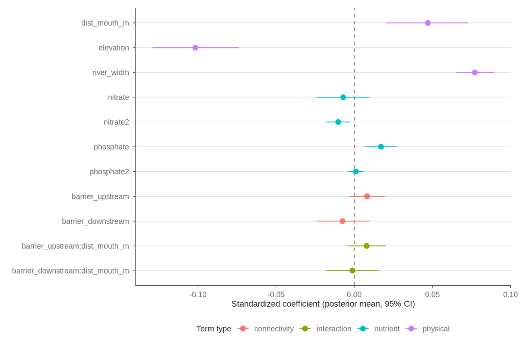

```r
plot_coefficients(
  fit_richness, "Standardized coefficient (posterior mean, 95% CI)"
)
```

## Connectance model

$$\text{connectance}_i \sim \text{Beta}(\mu_i, \phi)$$
$$\text{logit}(\mu_i) = \gamma_r \, \text{richness}_i +
\mathbf{x}_i^\top \boldsymbol\gamma +
\text{year}_i + \text{district}_i + \text{SPDE}_i$$

where $\mu_i \in (0, 1)$ is the mean and $\phi$ a shared precision hyperparameter. We include richness in the model as mediator variable, so we can disentangle direct and richness-mediated effect of stressors on food web structure.

We first prepare the data for the model.

```r
connectance_vars <- c(
  "connectance", "log_species_richness", "elevation", "river_width",
  "nitrate", "phosphate",
  "barrier_upstream", "barrier_downstream",
  "dist_mouth_m", "year", "sandre_code", "district"
)
river_connectance_data <- river_data |>
  filter(complete.cases(river_data[connectance_vars]))

river_connectance_data <- river_connectance_data |>
  mutate(
    nitrate = log(nitrate),
    phosphate = log(phosphate),
    barrier_upstream = log1p(barrier_upstream),
    barrier_downstream = log1p(barrier_downstream),
    river_width = log(river_width),
    district_id = as.integer(factor(district))
  ) |>
  mutate(across(
    c(
      log_species_richness, nitrate, phosphate,
      barrier_upstream, barrier_downstream,
      dist_mouth_m, elevation, river_width
    ),
    \(x) as.numeric(scale(x))
  )) |>
  mutate(nitrate2 = nitrate^2, phosphate2 = phosphate^2)

site_idx_connectance <- match(
  river_connectance_data$sandre_code, stations$sandre_code
)
A_connectance <- A[site_idx_connectance, ]
```

Then, we define and fit the model.

```r
connectance_stack <- inla.stack(
  data = list(y = river_connectance_data$connectance),
  A = list(A_connectance, 1),
  effects = list(
    spatial.field = spatial_index,
    data.frame(
      intercept = 1,
      log_species_richness = river_connectance_data$log_species_richness,
      elevation = river_connectance_data$elevation,
      river_width = river_connectance_data$river_width,
      nitrate = river_connectance_data$nitrate,
      nitrate2 = river_connectance_data$nitrate2,
      phosphate = river_connectance_data$phosphate,
      phosphate2 = river_connectance_data$phosphate2,
      barrier_upstream = river_connectance_data$barrier_upstream,
      barrier_downstream = river_connectance_data$barrier_downstream,
      dist_mouth_m = river_connectance_data$dist_mouth_m,
      year = river_connectance_data$year,
      district_id = river_connectance_data$district_id
    )
  ),
  tag = "est"
)

fit_connectance <- inla(
  y ~ -1 + intercept + log_species_richness + elevation + river_width +
    nitrate + nitrate2 + phosphate + phosphate2 +
    barrier_upstream + barrier_downstream +
    dist_mouth_m +
    barrier_upstream:dist_mouth_m +
    barrier_downstream:dist_mouth_m +
    f(year, model = "iid") +
    f(district_id, model = "iid") +
    f(spatial.field, model = spde),
  family = "beta",
  data = inla.stack.data(connectance_stack),
  control.predictor = list(A = inla.stack.A(connectance_stack), compute = TRUE),
  control.compute = list(waic = TRUE, config = TRUE, cpo = TRUE)
)
```

We show the model fixed effects below.

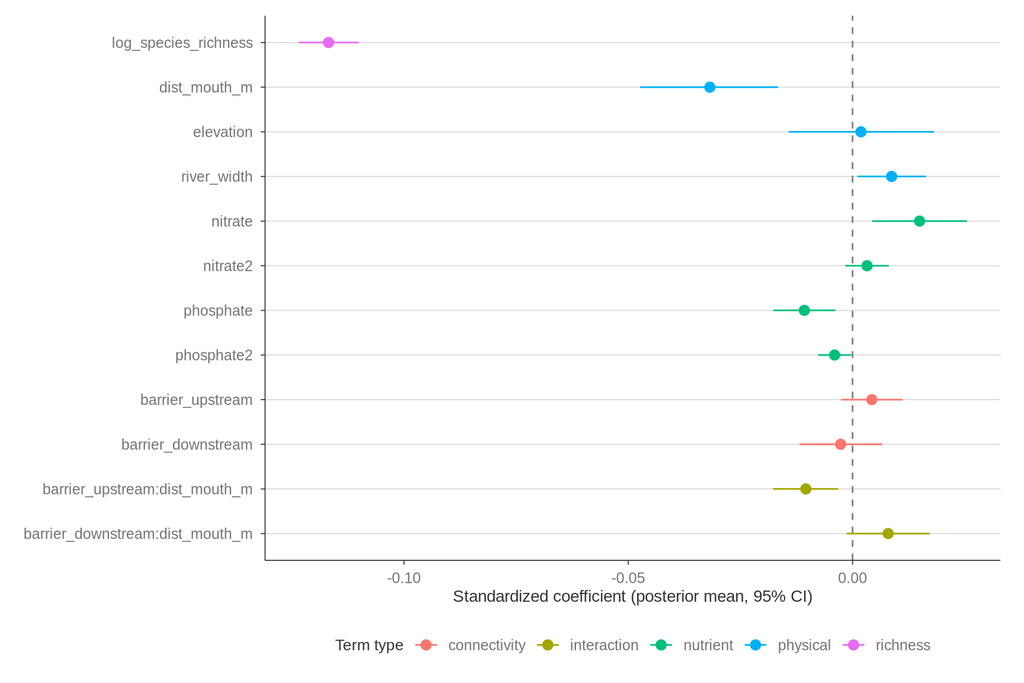

```r
plot_coefficients(
  fit_connectance, "Standardized coefficient (posterior mean, 95% CI)"
)
```

### Sanity check

Before that we run a quick sanity check to ensure that our gaussian random field capture properly the residual spatial structure, and so that no large spatial struture (e.g. basin scale) remains.

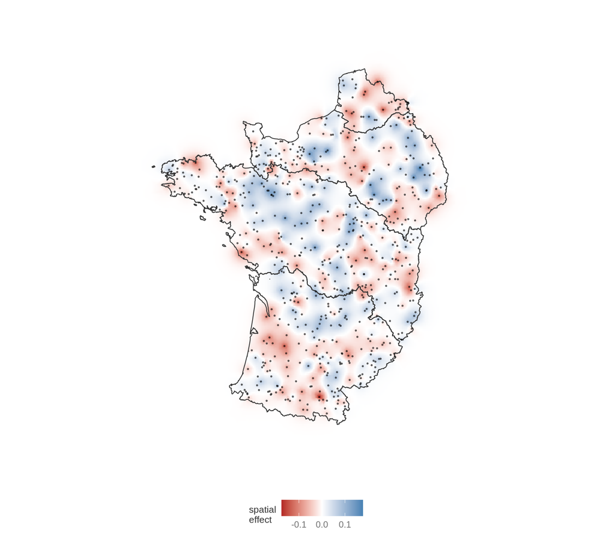

```r
proj <- inla.mesh.projector(mesh, dims = c(300, 300))
field_grid <- inla.mesh.project(
  proj, fit_connectance$summary.random$spatial.field$mean
)
grid_df <- expand.grid(x = proj$x, y = proj$y)
grid_df$z <- as.vector(field_grid)
grid_df <- grid_df |> filter(!is.na(z))

basin_connectance <- basin |>
  filter(district %in% unique(river_connectance_data$district)) |>
  st_transform(2154)
stations_connectance <- stations |>
  filter(sandre_code %in% river_connectance_data$sandre_code)

ggplot() +
  geom_raster(data = grid_df, aes(x, y, fill = z)) +
  scale_fill_gradient2(
    low = "firebrick", mid = "white", high = "steelblue", midpoint = 0
  ) +
  geom_sf(data = basin_connectance, fill = NA, color = "grey20", linewidth = 0.4) +
  geom_sf(data = stations_connectance, size = 0.4, alpha = 0.5, color = "black") +
  coord_sf(crs = 2154, datum = NA) +
  labs(
    x = NULL, y = NULL, fill = "spatial\neffect"
  )
```

We observe no large spatial structure, meaning that the spatial random field does the work.

### Interaction AME setup

```r
conn_main_vars <- c(
  "log_species_richness", "elevation", "river_width",
  "nitrate", "phosphate",
  "barrier_upstream", "barrier_downstream",
  "dist_mouth_m"
)
conn_inter_pairs <- list(
  c("barrier_upstream", "dist_mouth_m"),
  c("barrier_downstream", "dist_mouth_m")
)
conn_inter_names <- sapply(conn_inter_pairs, \(p) paste0(p[1], ":", p[2]))
conn_quad_vars <- c("nitrate", "phosphate")
conn_quad_names <- paste0(conn_quad_vars, "2")

X_conn <- as.matrix(river_connectance_data[conn_main_vars])
colnames(X_conn) <- conn_main_vars
year_levels_conn <- sort(unique(river_connectance_data$year))
year_idx_conn <- match(river_connectance_data$year, year_levels_conn)
district_idx_conn <- river_connectance_data$district_id

extract_conn <- function(s) {
  list(
    intercept = get_val(s, "intercept"),
    betas = setNames(sapply(conn_main_vars, \(v) get_val(s, v)), conn_main_vars),
    inter_betas = setNames(
      sapply(conn_inter_pairs, \(p) get_val(s, paste0(p[1], ":", p[2]))), conn_inter_names
    ),
    quad_betas = setNames(sapply(conn_quad_names, \(v) get_val(s, v)), conn_quad_names),
    re_offset = get_re_vec(s, "year", length(year_levels_conn))[year_idx_conn] +
      get_re_vec(s, "district_id", 4)[district_idx_conn] +
      as.numeric(A_connectance %*% get_spatial_vec(s))
  )
}

linpred_conn <- function(Xmat, betas, inter_betas, quad_betas) {
  out <- as.numeric(Xmat %*% betas[conn_main_vars])
  for (k in seq_along(conn_inter_pairs)) {
    p <- conn_inter_pairs[[k]]
    out <- out + (Xmat[, p[1]] * Xmat[, p[2]]) * inter_betas[k]
  }
  for (k in seq_along(conn_quad_vars)) {
    out <- out + (Xmat[, conn_quad_vars[k]]^2) * quad_betas[k]
  }
  out
}

predicted_conn <- function(Xmat, cd) {
  eta <- cd$intercept + linpred_conn(Xmat, cd$betas, cd$inter_betas, cd$quad_betas) + cd$re_offset
  plogis(eta)
}
```

```r
n_ame_draws_conn <- 300
ame_eps_conn <- 0.02
set.seed(1)
ps_conn <- inla.posterior.sample(n_ame_draws_conn, fit_connectance)
cd_list <- lapply(ps_conn, extract_conn)

dist_mouth_levels_conn <- quantile(river_connectance_data$dist_mouth_m, probs = c(0.1, 0.5, 0.9))
level_labels <- c("low", "median", "high")

rows <- list()
for (pair_idx in seq_along(conn_inter_pairs)) {
  var <- conn_inter_pairs[[pair_idx]][1]
  for (lvl_idx in seq_along(dist_mouth_levels_conn)) {
    lvl <- dist_mouth_levels_conn[lvl_idx]
    draws <- numeric(n_ame_draws_conn)
    for (m in seq_len(n_ame_draws_conn)) {
      cd <- cd_list[[m]]
      X_plus <- X_conn; X_plus[, var] <- X_plus[, var] + ame_eps_conn
      X_plus[, "dist_mouth_m"] <- lvl
      X_minus <- X_conn; X_minus[, var] <- X_minus[, var] - ame_eps_conn
      X_minus[, "dist_mouth_m"] <- lvl
      pred_plus <- predicted_conn(X_plus, cd)
      pred_minus <- predicted_conn(X_minus, cd)
      draws[m] <- mean((pred_plus - pred_minus) / (2 * ame_eps_conn))
    }
    rows[[length(rows) + 1]] <- tibble(
      var = var, dist_mouth_level = level_labels[lvl_idx],
      dist_mouth_value = as.numeric(lvl), mean = mean(draws),
      `0.025quant` = quantile(draws, 0.025),
      `0.975quant` = quantile(draws, 0.975)
    )
  }
}
interaction_ame_conn <- bind_rows(rows) |>
  mutate(dist_mouth_level = factor(dist_mouth_level, levels = level_labels))
```

## Trophic length model

We model trophic lengths in two distinct parts as it is trimodal. The ordinal part models the `predation_depth`, that is, whether the community has: 1) no species eating fish species; 2) a fish species eating a non-piscivorous; 3) a fish species eating a piscivorous species. Then, knowing this category, we model trophic length as a conditional gaussian distribution.

### Ordinal part

With $D_i \in \{1, 2, 3\}$ the predation-depth category (no fish eaten / eats a non-piscivorous fish / eats a piscivorous fish) of operation $i$, a proportional-odds (cumulative logit) model:

$$\text{logit}\left[P(D_i \le k)\right] = \theta_k - \eta_i,
\quad k \in \{1, 2\}$$
$$\eta_i = \mathbf{x}_i^\top \boldsymbol\beta +
\text{year}_i + \text{district}_i +
\text{SPDE}_i$$

We first prepare the data,

```r
tl_vars <- c(
  "log_species_richness", "elevation", "river_width",
  "nitrate", "phosphate",
  "barrier_upstream", "barrier_downstream",
  "dist_mouth_m", "year", "sandre_code", "district"
)
river_tl_foodweb <- river_foodweb |>
  st_drop_geometry() |>
  select(operation_id, predation_depth)

river_tl_data <- river_data |>
  filter(complete.cases(river_data[tl_vars])) |>
  left_join(river_tl_foodweb, by = "operation_id")

river_tl_data <- river_tl_data |>
  mutate(
    nitrate = log(nitrate),
    phosphate = log(phosphate),
    barrier_upstream = log1p(barrier_upstream),
    barrier_downstream = log1p(barrier_downstream),
    river_width = log(river_width),
    district_id = as.integer(factor(district)),
    predation_depth_int = as.integer(predation_depth)
  ) |>
  mutate(across(
    c(
      log_species_richness, nitrate, phosphate,
      barrier_upstream, barrier_downstream,
      dist_mouth_m, elevation, river_width
    ),
    \(x) as.numeric(scale(x))
  )) |>
  mutate(nitrate2 = nitrate^2, phosphate2 = phosphate^2)

site_idx_tl <- match(river_tl_data$sandre_code, stations$sandre_code)
A_tl <- A[site_idx_tl, ]

tl_covariate_df <- data.frame(
  log_species_richness = river_tl_data$log_species_richness,
  elevation = river_tl_data$elevation,
  river_width = river_tl_data$river_width,
  nitrate = river_tl_data$nitrate,
  nitrate2 = river_tl_data$nitrate2,
  phosphate = river_tl_data$phosphate,
  phosphate2 = river_tl_data$phosphate2,
  barrier_upstream = river_tl_data$barrier_upstream,
  barrier_downstream = river_tl_data$barrier_downstream,
  dist_mouth_m = river_tl_data$dist_mouth_m,
  year = river_tl_data$year,
  district_id = river_tl_data$district_id
)
```

then define and fit the model,

```r
stk_ordinal <- inla.stack(
  data = list(y = river_tl_data$predation_depth_int),
  A = list(A_tl, 1),
  effects = list(spatial.field = spatial_index, tl_covariate_df),
  tag = "est"
)

fit_predation_depth <- inla(
  y ~ log_species_richness + elevation + river_width +
    nitrate + nitrate2 + phosphate + phosphate2 +
    barrier_upstream + barrier_downstream +
    dist_mouth_m +
    barrier_upstream:dist_mouth_m +
    barrier_downstream:dist_mouth_m +
    f(year, model = "iid") +
    f(district_id, model = "iid") +
    f(spatial.field, model = spde),
  family = "pom",
  data = inla.stack.data(stk_ordinal),
  control.predictor = list(A = inla.stack.A(stk_ordinal), compute = TRUE),
  control.compute = list(waic = TRUE, config = TRUE)
)
```

```
 *** inla.core.safe:  The inla program failed, but will rerun in case better initial values may help. try=1/1
```

```
 *** inla.core.safe:  rerun with improved initial values
```

and plot its fixed effects.

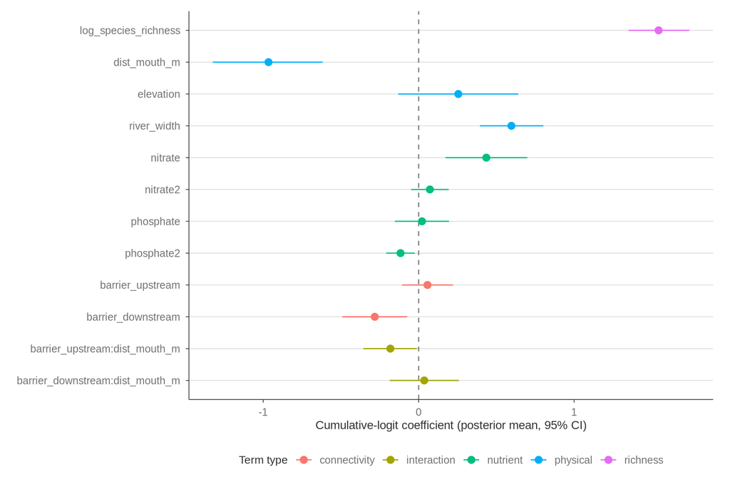

```r
plot_coefficients(
  fit_predation_depth, "Cumulative-logit coefficient (posterior mean, 95% CI)"
)
```

For nutrients, we observe a positive effect of nitrate which is consistent with its impact on connectance. Phosphate has a humped-shape effect on trophic length. We observe a negative of barrier downstream, consistent with the trapping hypothesis discussed in the connectance model. We expect this effect to decreases as we move upstream.

But before that, we have a look at the model parameters to ensure that the category inferred make sense. First, the mean and standard deviation of $\theta$. Second, the probability of belonging to each category $p$ (on average), which should roughly correspond to what is observed in the data.

```r
thresholds <- fit_predation_depth$summary.hyperpar |>
  tibble::rownames_to_column("term") |>
  filter(grepl("POM", term)) |>
  select(term, mean, sd, `0.025quant`, `0.975quant`)
thresholds |> knitr::kable(digits = 3)
```

| term | mean | sd | 0.025quant | 0.975quant |
| --- | --- | --- | --- | --- |
| theta1 for POM | -2.755 | 1.223 | -5.122 | -0.306 |
| theta2 for POM | 1.709 | 0.037 | 1.635 | 1.782 |

```r
# implied category split at eta = 0 (an "average-covariate" site)
p_le1 <- plogis(thresholds$mean[1])
p_le2 <- plogis(thresholds$mean[2])
tibble(
  predation_depth = levels(river_tl_data$predation_depth),
  p = c(p_le1, p_le2 - p_le1, 1 - p_le2)
) |>
  knitr::kable(digits = 3)
```

| predation_depth | p |
| --- | --- |
| no fish eaten | 0.060 |
| eats a non-piscivorous fish | 0.787 |
| eats a piscivorous fish | 0.153 |

Next, we have a look at the gaussian part of the model, conditioned on the predation depth category.

### Conditional gaussian part

Conditional on the mode $D_i$, a Gaussian for the continuous variation within a mode, with a separate intercept per category (no shared global intercept, since the three category dummies already span that) and the same covariates and random-effect structure:

$$\text{trophic\_length}_i \mid D_i \sim \mathcal{N}(\mu_i, \sigma^2)$$
$$\mu_i = \alpha_{D_i} + \mathbf{x}_i^\top \boldsymbol\gamma +
\text{year}_i + \text{district}_i + \text{SPDE}_i$$

We fit the model,

```r
tl_covariate_df$predation_depth <- river_tl_data$predation_depth

stk_tl <- inla.stack(
  data = list(y = river_tl_data$trophic_length),
  A = list(A_tl, 1),
  effects = list(spatial.field = spatial_index, tl_covariate_df),
  tag = "est"
)

fit_trophic_length <- inla(
  y ~ -1 + predation_depth + log_species_richness + elevation +
    river_width +
    nitrate + nitrate2 + phosphate + phosphate2 +
    barrier_upstream + barrier_downstream +
    dist_mouth_m +
    barrier_upstream:dist_mouth_m +
    barrier_downstream:dist_mouth_m +
    f(year, model = "iid") +
    f(district_id, model = "iid") +
    f(spatial.field, model = spde),
  family = "gaussian",
  data = inla.stack.data(stk_tl),
  control.predictor = list(A = inla.stack.A(stk_tl), compute = TRUE),
  control.compute = list(waic = TRUE, config = TRUE)
)
```

and plot its fixed effects.

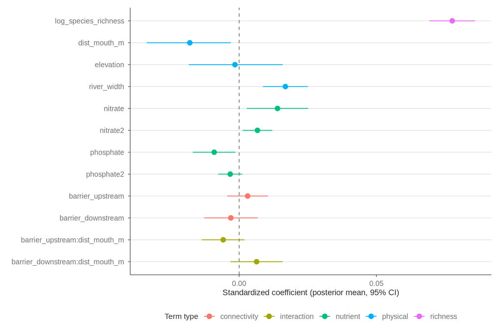

```r
plot_coefficients(
  fit_trophic_length, "Standardized coefficient (posterior mean, 95% CI)"
)
```

`plot_coefficients()` drops the three `predation_depth` category intercepts (not in `term_order` - they’re baseline levels, not effects on the same scale as the covariates), so they’re reported separately:

```r
fit_trophic_length$summary.fixed |>
  tibble::rownames_to_column("term") |>
  filter(grepl("^predation_depth", term)) |>
  select(term, mean, sd, `0.025quant`, `0.975quant`) |>
  knitr::kable(digits = 3)
```

| term | mean | sd | 0.025quant | 0.975quant |
| --- | --- | --- | --- | --- |
| predation_depthno fish eaten | 4.029 | 0.017 | 3.996 | 4.063 |
| predation_deptheats a non-piscivorous fish | 4.787 | 0.011 | 4.764 | 4.809 |
| predation_deptheats a piscivorous fish | 5.241 | 0.011 | 5.218 | 5.263 |

*To discuss: the three category intercepts should closely match the histogram modes from the checkpoint above, a good consistency check; which covariates have a credible effect on trophic_length once the mode itself is accounted for, versus the ordinal model’s list above - several covariates that look credible for shifting the mode may not have an additional within-mode effect, or vice versa.*

### Average marginal effect

Neither model alone gives a covariate’s *total* effect on `trophic_length`: the ordinal model gives its effect on which mode a web reaches, the Gaussian gives its effect within a mode. Combining them requires simulation, not a coefficient product, because the mode-shift component is a non-linear function of $x_i$ itself:

$$E[\text{trophic\_length}_i \mid x_i] =
\sum_{k=1}^{3} P(D_i = k \mid x_i) \cdot \mu_{i,k}$$

We compute the average marginal effect (AME) of each covariate $x_j$ as the average, over all sites and over posterior draws sampled independently from both models, of the numerical derivative of this mixture expectation with respect to $x_j$ (central difference, small step on the standardized scale). Treating the two models’ posteriors as independent is an approximation - it ignores any correlation between their uncertainty, since they were not fit jointly.

```r
main_vars <- c(
  "log_species_richness", "elevation", "river_width",
  "nitrate", "phosphate",
  "barrier_upstream", "barrier_downstream",
  "dist_mouth_m"
)
inter_pairs <- list(
  c("barrier_upstream", "dist_mouth_m"),
  c("barrier_downstream", "dist_mouth_m")
)
inter_names <- sapply(inter_pairs, \(p) paste0(p[1], ":", p[2]))
# quadratic terms are derived from a main_vars column (x^2), not
# independently perturbable - handled like interactions, not like main_vars
quad_vars <- c("nitrate", "phosphate")
quad_names <- paste0(quad_vars, "2")

X_tl <- as.matrix(river_tl_data[main_vars])
colnames(X_tl) <- main_vars
year_levels_tl <- sort(unique(river_tl_data$year))
year_idx_tl <- match(river_tl_data$year, year_levels_tl)
district_idx_tl <- river_tl_data$district_id

# everything x-independent from one ordinal posterior draw
extract_pd <- function(s) {
  list(
    intercept = get_val(s, "(Intercept)"),
    betas = setNames(sapply(main_vars, \(v) get_val(s, v)), main_vars),
    inter_betas = setNames(
      sapply(inter_pairs, \(p) get_val(s, paste0(p[1], ":", p[2]))), inter_names
    ),
    quad_betas = setNames(sapply(quad_names, \(v) get_val(s, v)), quad_names),
    re_offset = get_re_vec(s, "year", length(year_levels_tl))[year_idx_tl] +
      get_re_vec(s, "district_id", 4)[district_idx_tl] +
      as.numeric(A_tl %*% get_spatial_vec(s)),
    theta1 = s$hyperpar["theta1 for POM"],
    theta2 = s$hyperpar["theta2 for POM"]
  )
}
# everything x-independent from one conditional-gaussian posterior draw
extract_tl <- function(s) {
  list(
    alpha = c(
      get_val(s, "predation_depthno fish eaten"),
      get_val(s, "predation_deptheats a non-piscivorous fish"),
      get_val(s, "predation_deptheats a piscivorous fish")
    ),
    betas = setNames(sapply(main_vars, \(v) get_val(s, v)), main_vars),
    inter_betas = setNames(
      sapply(inter_pairs, \(p) get_val(s, paste0(p[1], ":", p[2]))), inter_names
    ),
    quad_betas = setNames(sapply(quad_names, \(v) get_val(s, v)), quad_names),
    re_offset = get_re_vec(s, "year", length(year_levels_tl))[year_idx_tl] +
      get_re_vec(s, "district_id", 4)[district_idx_tl] +
      as.numeric(A_tl %*% get_spatial_vec(s))
  )
}

linpred_main <- function(Xmat, betas, inter_betas, quad_betas) {
  out <- as.numeric(Xmat %*% betas[main_vars])
  for (k in seq_along(inter_pairs)) {
    p <- inter_pairs[[k]]
    out <- out + (Xmat[, p[1]] * Xmat[, p[2]]) * inter_betas[k]
  }
  for (k in seq_along(quad_vars)) {
    out <- out + (Xmat[, quad_vars[k]]^2) * quad_betas[k]
  }
  out
}

predicted_tl <- function(Xmat, pd, tl) {
  eta <- pd$intercept +
    linpred_main(Xmat, pd$betas, pd$inter_betas, pd$quad_betas) + pd$re_offset
  p_le1 <- plogis(pd$theta1 - eta)
  p_le2 <- plogis(pd$theta2 - eta)
  p1 <- p_le1
  p2 <- p_le2 - p_le1
  p3 <- 1 - p_le2
  shared <- linpred_main(Xmat, tl$betas, tl$inter_betas, tl$quad_betas) +
    tl$re_offset
  p1 * (tl$alpha[1] + shared) +
    p2 * (tl$alpha[2] + shared) +
    p3 * (tl$alpha[3] + shared)
}
```

```r
n_ame_draws <- 300
ame_eps <- 0.02
set.seed(1)
ps_pd <- inla.posterior.sample(n_ame_draws, fit_predation_depth)
ps_tl <- inla.posterior.sample(n_ame_draws, fit_trophic_length)

ame_draws <- matrix(
  NA, nrow = n_ame_draws, ncol = length(main_vars),
  dimnames = list(NULL, main_vars)
)
for (m in seq_len(n_ame_draws)) {
  pd <- extract_pd(ps_pd[[m]])
  tl <- extract_tl(ps_tl[[m]])
  for (j in main_vars) {
    X_plus <- X_tl; X_plus[, j] <- X_plus[, j] + ame_eps
    X_minus <- X_tl; X_minus[, j] <- X_minus[, j] - ame_eps
    pred_plus <- predicted_tl(X_plus, pd, tl)
    pred_minus <- predicted_tl(X_minus, pd, tl)
    ame_draws[m, j] <- mean((pred_plus - pred_minus) / (2 * ame_eps))
  }
}

ame_summary <- tibble(
  term = main_vars,
  mean = apply(ame_draws, 2, mean),
  `0.025quant` = apply(ame_draws, 2, quantile, 0.025),
  `0.975quant` = apply(ame_draws, 2, quantile, 0.975)
)
ame_summary |> knitr::kable(digits = 3)
```

| term | mean | 0.025quant | 0.975quant |
| --- | --- | --- | --- |
| log_species_richness | 0.183 | 0.147 | 0.220 |
| elevation | 0.015 | -0.017 | 0.046 |
| river_width | 0.058 | 0.037 | 0.080 |
| nitrate | 0.041 | 0.019 | 0.062 |
| phosphate | -0.006 | -0.019 | 0.008 |
| barrier_upstream | 0.005 | -0.008 | 0.022 |
| barrier_downstream | -0.022 | -0.045 | -0.003 |
| dist_mouth_m | -0.083 | -0.126 | -0.052 |

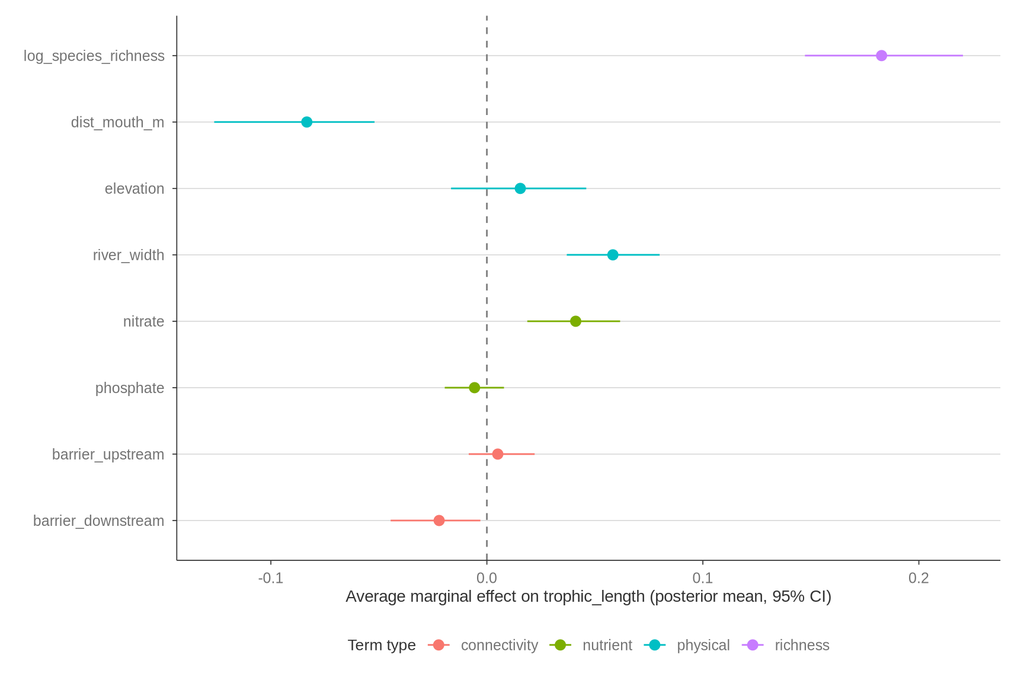

```r
ame_fit <- list(summary.fixed = data.frame(
  mean = ame_summary$mean,
  `0.025quant` = ame_summary$`0.025quant`,
  `0.975quant` = ame_summary$`0.975quant`,
  row.names = ame_summary$term,
  check.names = FALSE
))
plot_coefficients(
  ame_fit,
  "Average marginal effect on trophic_length (posterior mean, 95% CI)"
)
```

### Interaction AME setup

Reused later by the combined dam/barrier interaction figure at the end of the notebook - no standalone result here.

```r
dist_mouth_levels <- quantile(river_tl_data$dist_mouth_m, probs = c(0.1, 0.5, 0.9))
level_labels <- c("low", "median", "high")

pd_list <- lapply(ps_pd, extract_pd)
tl_list <- lapply(ps_tl, extract_tl)

rows <- list()
for (pair_idx in seq_along(inter_pairs)) {
  var <- inter_pairs[[pair_idx]][1]
  for (lvl_idx in seq_along(dist_mouth_levels)) {
    lvl <- dist_mouth_levels[lvl_idx]
    draws <- numeric(n_ame_draws)
    for (m in seq_len(n_ame_draws)) {
      pd <- pd_list[[m]]; tl <- tl_list[[m]]
      X_plus <- X_tl; X_plus[, var] <- X_plus[, var] + ame_eps
      X_plus[, "dist_mouth_m"] <- lvl
      X_minus <- X_tl; X_minus[, var] <- X_minus[, var] - ame_eps
      X_minus[, "dist_mouth_m"] <- lvl
      pred_plus <- predicted_tl(X_plus, pd, tl)
      pred_minus <- predicted_tl(X_minus, pd, tl)
      draws[m] <- mean((pred_plus - pred_minus) / (2 * ame_eps))
    }
    rows[[length(rows) + 1]] <- tibble(
      var = var, dist_mouth_level = level_labels[lvl_idx],
      dist_mouth_value = as.numeric(lvl), mean = mean(draws),
      `0.025quant` = quantile(draws, 0.025),
      `0.975quant` = quantile(draws, 0.975)
    )
  }
}
interaction_ame <- bind_rows(rows) |>
  mutate(dist_mouth_level = factor(dist_mouth_level, levels = level_labels))
```

## Nutrient curvature effect

Both `nitrate`/`nitrate2` and `phosphate`/`phosphate2` mean a single coefficient doesn’t capture their effect - the same reasoning as the dam/barrier interactions above, just a self-interaction (curvature) instead of a two-way one, so there’s no second variable to hold fixed. Instead, for richness, connectance and trophic_length alike, we discretize the dose-response curve into the AME of each nutrient evaluated locally at its own 10th/50th/90th percentile - does the *slope* of the nutrient’s effect change across its own range.

```r
own_curvature_ame <- function(v, X_base, predicted_fn, draw_list, eps = 0.02,
                               probs = c(0.1, 0.5, 0.9),
                               level_labels = c("low", "median", "high")) {
  levels_v <- quantile(X_base[, v], probs = probs)
  rows <- list()
  for (lvl_idx in seq_along(levels_v)) {
    lvl <- levels_v[lvl_idx]
    draws <- sapply(draw_list, \(obj) {
      X_plus <- X_base; X_plus[, v] <- lvl + eps
      X_minus <- X_base; X_minus[, v] <- lvl - eps
      mean((predicted_fn(X_plus, obj) - predicted_fn(X_minus, obj)) / (2 * eps))
    })
    rows[[lvl_idx]] <- tibble(
      var = v, level = level_labels[lvl_idx], value = as.numeric(lvl),
      mean = mean(draws),
      `0.025quant` = quantile(draws, 0.025),
      `0.975quant` = quantile(draws, 0.975)
    )
  }
  bind_rows(rows) |> mutate(level = factor(level, levels = level_labels))
}

rich_main_vars <- c(
  "elevation", "river_width", "nitrate", "phosphate",
  "barrier_upstream", "barrier_downstream",
  "dist_mouth_m"
)
rich_inter_pairs <- list(
  c("barrier_upstream", "dist_mouth_m"),
  c("barrier_downstream", "dist_mouth_m")
)
rich_inter_names <- sapply(rich_inter_pairs, \(p) paste0(p[1], ":", p[2]))
rich_quad_vars <- c("nitrate", "phosphate")
rich_quad_names <- paste0(rich_quad_vars, "2")

X_rich <- as.matrix(river_model_data[rich_main_vars])
colnames(X_rich) <- rich_main_vars
year_levels_rich <- sort(unique(river_model_data$year))
year_idx_rich <- match(river_model_data$year, year_levels_rich)
district_idx_rich <- river_model_data$district_id

extract_rich <- function(s) {
  list(
    intercept = get_val(s, "intercept"),
    betas = setNames(sapply(rich_main_vars, \(v) get_val(s, v)), rich_main_vars),
    inter_betas = setNames(
      sapply(rich_inter_pairs, \(p) get_val(s, paste0(p[1], ":", p[2]))), rich_inter_names
    ),
    quad_betas = setNames(sapply(rich_quad_names, \(v) get_val(s, v)), rich_quad_names),
    re_offset = get_re_vec(s, "year", length(year_levels_rich))[year_idx_rich] +
      get_re_vec(s, "district_id", 4)[district_idx_rich] +
      as.numeric(A_model %*% get_spatial_vec(s))
  )
}
linpred_rich <- function(Xmat, betas, inter_betas, quad_betas) {
  out <- as.numeric(Xmat %*% betas[rich_main_vars])
  for (k in seq_along(rich_inter_pairs)) {
    p <- rich_inter_pairs[[k]]
    out <- out + (Xmat[, p[1]] * Xmat[, p[2]]) * inter_betas[k]
  }
  for (k in seq_along(rich_quad_vars)) out <- out + (Xmat[, rich_quad_vars[k]]^2) * quad_betas[k]
  out
}
predicted_rich <- function(Xmat, rd) {
  rd$intercept + linpred_rich(Xmat, rd$betas, rd$inter_betas, rd$quad_betas) + rd$re_offset
}

n_rich_draws <- 300
set.seed(1)
ps_richness <- inla.posterior.sample(n_rich_draws, fit_richness)
rd_list <- lapply(ps_richness, extract_rich)
```

```r
nutrient_vars <- c("nitrate", "phosphate")

predicted_tl_paired <- function(Xmat, obj) predicted_tl(Xmat, obj$pd, obj$tl)
tl_draw_pairs <- Map(function(pd, tl) list(pd = pd, tl = tl), pd_list, tl_list)

curvature_for <- function(X_base, predicted_fn, draw_list, outcome_name) {
  bind_rows(lapply(
    nutrient_vars, own_curvature_ame,
    X_base = X_base, predicted_fn = predicted_fn, draw_list = draw_list
  )) |>
    mutate(outcome = outcome_name)
}

nutrient_curvature <- bind_rows(
  curvature_for(X_rich, predicted_rich, rd_list, "richness"),
  curvature_for(X_conn, predicted_conn, cd_list, "connectance"),
  curvature_for(X_tl, predicted_tl_paired, tl_draw_pairs, "trophic_length")
) |>
  mutate(outcome = factor(
    outcome, levels = c("richness", "connectance", "trophic_length")
  ))
```

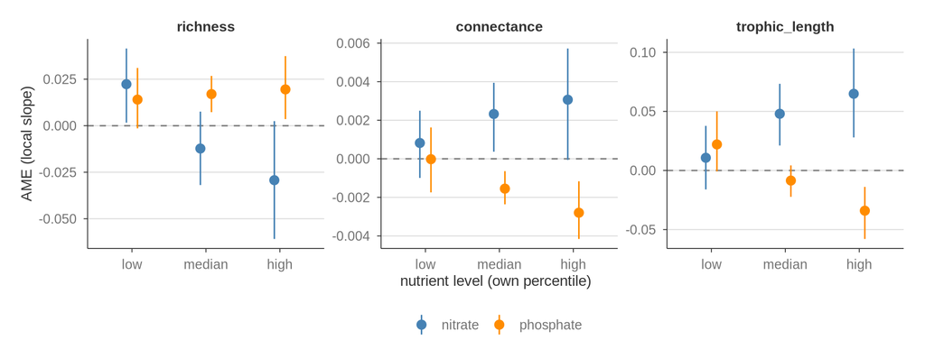

```r
nutrient_colors <- c(nitrate = "steelblue", phosphate = "darkorange")

ggplot(nutrient_curvature, aes(level, mean, color = var)) +
  geom_hline(yintercept = 0, linetype = "dashed", color = "grey50") +
  geom_pointrange(
    aes(ymin = `0.025quant`, ymax = `0.975quant`),
    position = position_dodge(width = 0.3)
  ) +
  scale_color_manual(values = nutrient_colors) +
  facet_wrap(~outcome, scales = "free_y") +
  labs(x = "nutrient level (own percentile)", y = "AME (local slope)", color = NULL)
```

## Dam interaction effect

Same simple-slopes approach as the nutrient curvature figure, but for the two barrier variables against `dist_mouth_m`: the AME of each, with `dist_mouth_m` held fixed at its 10th/50th/90th percentile instead of averaged over sites. Richness didn’t have this built yet, so we compute it here too, reusing the same setup as the nutrient curvature section above.

```r
dist_mouth_levels_rich <- quantile(river_model_data$dist_mouth_m, probs = c(0.1, 0.5, 0.9))
level_labels <- c("low", "median", "high")

rows <- list()
for (pair_idx in seq_along(rich_inter_pairs)) {
  var <- rich_inter_pairs[[pair_idx]][1]
  for (lvl_idx in seq_along(dist_mouth_levels_rich)) {
    lvl <- dist_mouth_levels_rich[lvl_idx]
    draws <- sapply(rd_list, \(rd) {
      X_plus <- X_rich; X_plus[, var] <- X_plus[, var] + 0.02
      X_plus[, "dist_mouth_m"] <- lvl
      X_minus <- X_rich; X_minus[, var] <- X_minus[, var] - 0.02
      X_minus[, "dist_mouth_m"] <- lvl
      mean((predicted_rich(X_plus, rd) - predicted_rich(X_minus, rd)) / (2 * 0.02))
    })
    rows[[length(rows) + 1]] <- tibble(
      var = var, level = level_labels[lvl_idx],
      mean = mean(draws),
      `0.025quant` = quantile(draws, 0.025),
      `0.975quant` = quantile(draws, 0.975)
    )
  }
}
dam_interaction_rich <- bind_rows(rows) |>
  mutate(level = factor(level, levels = level_labels))
```

```r
dam_interaction_all <- bind_rows(
  dam_interaction_rich |> mutate(outcome = "richness"),
  interaction_ame_conn |>
    rename(level = dist_mouth_level) |>
    select(var, level, mean, `0.025quant`, `0.975quant`) |>
    mutate(outcome = "connectance"),
  interaction_ame |>
    rename(level = dist_mouth_level) |>
    select(var, level, mean, `0.025quant`, `0.975quant`) |>
    mutate(outcome = "trophic_length")
) |>
  mutate(outcome = factor(outcome, levels = c("richness", "connectance", "trophic_length")))
```

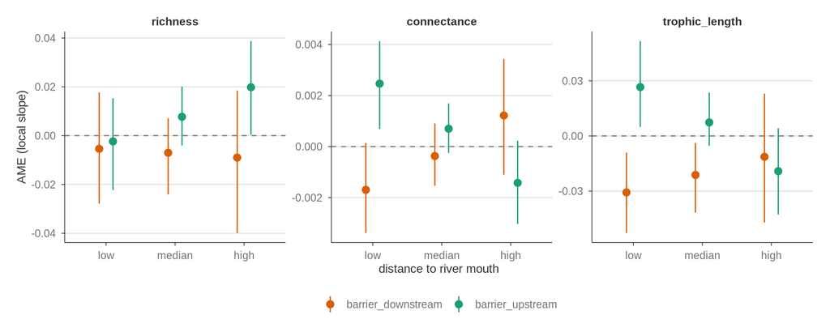

```r
dam_colors <- c(
  barrier_upstream = "#1b9e77",
  barrier_downstream = "#d95f02"
)

ggplot(dam_interaction_all, aes(level, mean, color = var)) +
  geom_hline(yintercept = 0, linetype = "dashed", color = "grey50") +
  geom_pointrange(
    aes(ymin = `0.025quant`, ymax = `0.975quant`),
    position = position_dodge(width = 0.4)
  ) +
  scale_color_manual(values = dam_colors) +
  facet_wrap(~outcome, scales = "free_y") +
  labs(x = "distance to river mouth", y = "AME (local slope)", color = NULL)
```

We observe that downstream barrier effect has a strong negative impact on connectance, and this effect vanishes at high distances. By constrast, the barrier upstream has a strong postive impact near the river mouth and this effect vanishes upstream. These patterns are constitent with the hypothesis that first dams from the river mouth trap migratory generalist predator, whose presence increases the connectance locally.

Both credible interactions found for trophic_length point the same direction, and match the same “trapping” hypothesis: dams filter out large, upstream-migrating predators, so they accumulate below the first dam they meet coming from the sea. Taller dams downstream of a site lower its trophic length (harder for predators from the sea to reach it), taller dams upstream raise it (predators blocked from going further accumulate in the reach below, including the site) - and both effects fade with distance to the mouth, consistent with dams mattering most where they sit closest to the sea-derived predator pool.

Still a hypothesis, not a conclusion: the data can’t rule out other differences correlated with tall dams (e.g. altered habitat immediately around them) as the actual driver.

## References

Bolin, David, Alexandre B. Simas, and Jonas Wallin. 2023. *Gaussian Whittle-Matérn Fields on Metric Graphs*. https://doi.org/10.48550/arXiv.2205.06163.